# Assignment 2.1

Manish Shah

2023-04-15

*Loading required library*

```r
library(tidyverse)
library(rvest)
library(xml2)
```

# Part 1:

### 1. Get this data in R, make it tidy and do the necessary transformations: https://www.mohfw.gov.in/”

Get json data

```r
covid_data <- jsonlite::fromJSON("https://www.mohfw.gov.in/data/datanew.json")
```

Convert json data to a data frame

```r
covid_df <- as.data.frame(covid_data)
```

Remove unnecessary columns. All the columns except **state_name, new_active, new_positive, new_cured, new_death** are removed

```r
covid_df <- covid_df[, c("state_name", "new_active", "new_positive", "new_cured", "new_death")]
```

Rename columns

```r
colnames(covid_df) <- c("state", "active", "confirmed", "recovered", "deaths")
```

Convert data types from character to numeric

```r
covid_df$active <- as.numeric(covid_df$active)
covid_df$confirmed <- as.numeric(covid_df$confirmed)
covid_df$recovered <- as.numeric(covid_df$recovered)
covid_df$deaths <- as.numeric(covid_df$deaths)
```

Adding text to last row as “Total”

```r
covid_df[nrow(covid_df), "state"] <- "Total"
```

Print covid_df

```r
knitr::kable(head(covid_df))
```

| state | active | confirmed | recovered | deaths |
| --- | --- | --- | --- | --- |
| Andaman and Nicobar Islands | 13 | 10764 | 10622 | 129 |
| Andhra Pradesh | 341 | 2339785 | 2324711 | 14733 |
| Arunachal Pradesh | 3 | 66895 | 66596 | 296 |
| Assam | 7 | 746112 | 738070 | 8035 |
| Bihar | 413 | 852078 | 839361 | 12304 |
| Chandigarh | 256 | 99924 | 98484 | 1184 |

### 2. Get this data in R, make it tidy and do the necessary transformation: https://covid19.who.int/table

Read the HTML code of the page

```r
page <- read_html("https://covid19.who.int/table")
```

Extract the div element containing the role=“table” data-attribute

```r
table_div <- page %>% html_nodes("div[role='table']")
```

Extract the column names from the table First & remove svg icons from thead

```r
remove_svg <- page %>% html_nodes("div.thead div.th svg")
xml_remove(remove_svg)
column_names <- table_div %>% html_nodes("div.thead div.th") %>% html_text()
```

Extract data i.e. table row (tr)

```r
table_rows <- page %>% html_nodes(".tr.depth_0")
table_rows <- table_rows[-c(1,2)]
```

Extract the child nodes and their text values from each row

```r
rows_data <- lapply(table_rows, function(row) {
  child_nodes <- row %>% html_children()
  child_values <- sapply(child_nodes, html_text)
  return(list(child_values))
  })
```

Convert the extracted data into a data frame

```r
table_df <- as.data.frame(rows_data)
```

Transpose the table_df & reset the row names to index and change the colnames to column_names extracted before

```r
table_df <- t(table_df)
rownames(table_df) <- NULL
colnames(table_df) <- column_names
```

Remove unnecessary columns & print table

```r
table_df <- table_df[, -c(3,5)]
knitr::kable(table_df)
```

| Name | Cases - cumulative total | Deaths - cumulative total | Total vaccine doses administered per 100 population | Persons fully vaccinated with last dose of primary series per 100 population | Persons Boosted per 100 population |
| --- | --- | --- | --- | --- | --- |
| United States of America | 102,873,924 | 1,118,800 | 201.37 | 68.8 | 35.09 |
| China | 99,239,252 | 120,905 | 238.97 | 87.3 | 56.67 |
| India | 44,768,172 | 531,000 | 159.9 | 68.99 | 16.57 |
| France | 38,791,479 | 162,176 | 234.5 | 78.98 | 60.91 |
| Germany | 38,368,891 | 171,411 | 232.3 | 76.42 | 62.68 |
| Brazil | 37,319,254 | 700,556 | 239.65 | 80.12 | 51.71 |
| Japan | 33,523,927 | 74,096 | 302.96 | 81.72 | 68.28 |
| Republic of Korea | 30,918,060 | 34,332 | 264.71 | 83.8 | 65.62 |
| Italy | 25,715,384 | 189,262 | 251.9 | 82.97 | 75.3 |
| The United Kingdom | 24,330,379 | 212,083 | 222.8 | 74.59 |  |
| Russian Federation | 22,727,542 | 397,642 | 127.7 | 54.54 |  |
| Türkiye | 17,004,677 | 101,419 |  | 60.94 | 33.55 |
| Spain | 13,798,747 | 120,426 | 238 | 79.18 | 56.06 |
| Viet Nam | 11,527,745 | 43,186 | 273.25 | 88.21 | 59.39 |
| Australia | 11,153,745 | 19,906 | 256.83 | 84.9 | 56.35 |
| Argentina | 10,044,957 | 130,472 | 242.62 | 83.72 | 68.17 |
| Netherlands | 8,610,372 | 22,992 | 207.4 | 68.69 | 54.1 |
| Iran (Islamic Republic of) | 7,597,982 | 145,571 | 187.86 | 69.7 | 37.33 |

### 3. Why the original version of the imbd dataset by Kaggle was taken down? https://www.kaggle.com/datasets/tmdb/tmdb-movie-metadata

As mentioned in “Data Source Transfer Summary”, Kaggle had used dataset from IMDB without IMDB permission due to which IMDB filed a takedown notice as per DMCA act.

### 4. Comment on this website’s web scrapping policy: https://help.imdb.com/article/imdb/general-information/can-i-use-imdb-data-in-my-software/G5JTRESSHJBBHTGX#

IMDB allows the data from https://contribute.imdb.com/dataset to be used for personal or educational purpose but doesn’t allow to use web scraping on their website. For commercial use, we can signup & get the API. Also, we must acknowledge the source of data where ever we use data from IMDB.

# Part 2:

*Setting woring directory to Documents/imdb*

```r
knitr::opts_knit$set(root.dir = "C:/Users/user/Documents/imdb")
```

### 8: Import title.ratings.tsv as df_ratings

```r
df_ratings <- read_tsv("title.ratings.tsv")
```

### 9: Check structure and summary & interpret

```r
str(df_ratings)
```

```
## spc_tbl_ [1,300,512 × 3] (S3: spec_tbl_df/tbl_df/tbl/data.frame)
##  $ tconst       : chr [1:1300512] "tt0000001" "tt0000002" "tt0000003" "tt0000004" ...
##  $ averageRating: num [1:1300512] 5.7 5.8 6.5 5.6 6.2 5.1 5.4 5.4 5.3 6.9 ...
##  $ numVotes     : num [1:1300512] 1965 262 1807 178 2603 ...
##  - attr(*, "spec")=
##   .. cols(
##   ..   tconst = col_character(),
##   ..   averageRating = col_double(),
##   ..   numVotes = col_double()
##   .. )
##  - attr(*, "problems")=<externalptr>
```

```r
summary(df_ratings)
```

```
##     tconst          averageRating      numVotes
##  Length:1300512     Min.   : 1.00   Min.   :      5
##  Class :character   1st Qu.: 6.20   1st Qu.:     11
##  Mode  :character   Median : 7.10   Median :     26
##                     Mean   : 6.95   Mean   :   1039
##                     3rd Qu.: 7.90   3rd Qu.:    101
##                     Max.   :10.00   Max.   :2726020
```

From structure, we can observer that there are 3 columns named tconst which is character, averageRating is numeric & numVotes is also numeric In Summary for numVotes, 3rd Quartile is 101 but the Max is 2726020 which denotes there is a outlier.

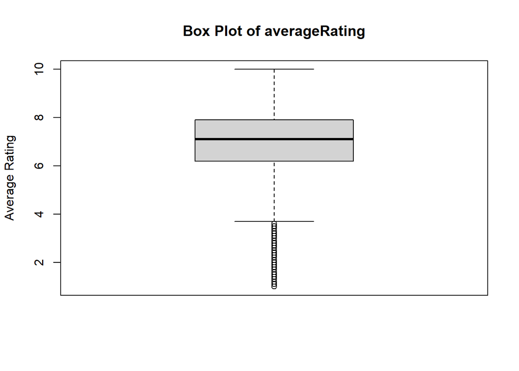

```r
boxplot(df_ratings$averageRating, main = "Box Plot of averageRating", ylab = "Average Rating")
```

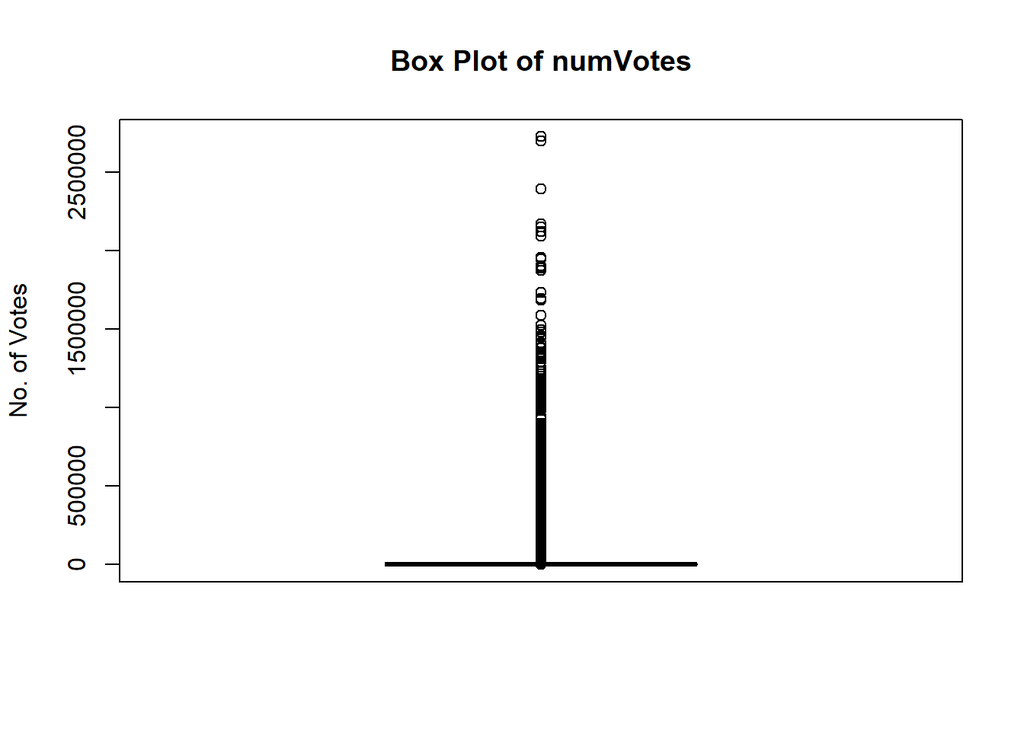

```r
boxplot(df_ratings$numVotes, main = "Box Plot of numVotes", ylab = "No. of Votes")
```

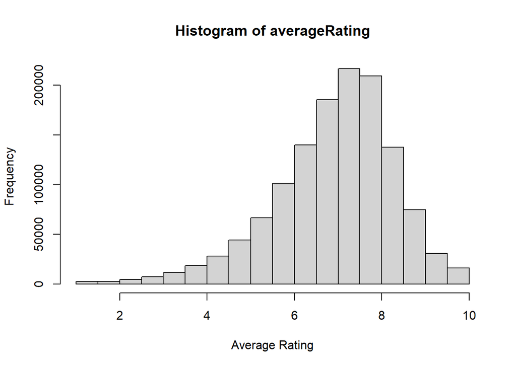

```r
hist(df_ratings$averageRating, main = "Histogram of averageRating", xlab = "Average Rating")
```

In summary for averageRating, there is extreme outliers as seen in the boxplot and skewed to left i.e negative skewness as seen in histogram

### 10: Is this dataset tidy?

```r
knitr::kable(head(df_ratings))
```

| tconst | averageRating | numVotes |
| --- | --- | --- |
| tt0000001 | 5.7 | 1965 |
| tt0000002 | 5.8 | 262 |
| tt0000003 | 6.5 | 1807 |
| tt0000004 | 5.6 | 178 |
| tt0000005 | 6.2 | 2603 |
| tt0000006 | 5.1 | 179 |

```r
any(is.na(df_ratings))
```

```
## [1] FALSE
```

Yes, the dataset is tidy according to the three rules that defines a tidy dataset.  
1. Each variable must have its own column.  
2. Each observation must have its own row.  
3. Each value must have its own cell.  
By checking head, we can see that every variable has it’s own column & using is.na() we can check if any value is missing or not.  
As there is not any missing value which means every row & column has value & every variable has it’s own column, so we can say that the data is tidy.

### 11: Create scatterplot of averageRating vs numVotes

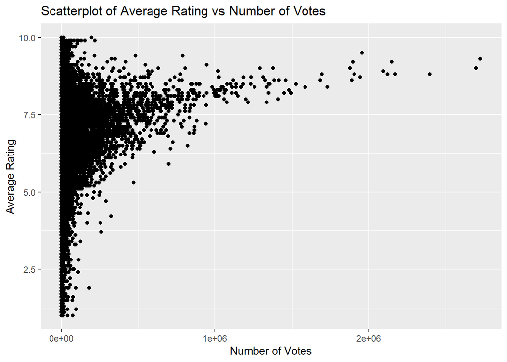

```r
ggplot(df_ratings, aes(x = numVotes, y = averageRating)) +
  geom_point() +
  xlab("Number of Votes") +
  ylab("Average Rating") +
  ggtitle("Scatterplot of Average Rating vs Number of Votes")
```

We can interpret from scatterplot that there is positive correlation i.e. as number of votes increases, average rating also increases

### 12: Import title.basics.tsv as df_basics

```r
df_basics <- read_tsv("title.basics.tsv")
```

### 13: Check the structure and get summary of all the variables and interpret them carefully

```r
str(df_basics)
```

```
## spc_tbl_ [9,770,643 × 9] (S3: spec_tbl_df/tbl_df/tbl/data.frame)
##  $ tconst        : chr [1:9770643] "tt0000001" "tt0000002" "tt0000003" "tt0000004" ...
##  $ titleType     : chr [1:9770643] "short" "short" "short" "short" ...
##  $ primaryTitle  : chr [1:9770643] "Carmencita" "Le clown et ses chiens" "Pauvre Pierrot" "Un bon bock" ...
##  $ originalTitle : chr [1:9770643] "Carmencita" "Le clown et ses chiens" "Pauvre Pierrot" "Un bon bock" ...
##  $ isAdult       : num [1:9770643] 0 0 0 0 0 0 0 0 0 0 ...
##  $ startYear     : chr [1:9770643] "1894" "1892" "1892" "1892" ...
##  $ endYear       : chr [1:9770643] "\\N" "\\N" "\\N" "\\N" ...
##  $ runtimeMinutes: chr [1:9770643] "1" "5" "4" "12" ...
##  $ genres        : chr [1:9770643] "Documentary,Short" "Animation,Short" "Animation,Comedy,Romance" "Animation,Short" ...
##  - attr(*, "spec")=
##   .. cols(
##   ..   tconst = col_character(),
##   ..   titleType = col_character(),
##   ..   primaryTitle = col_character(),
##   ..   originalTitle = col_character(),
##   ..   isAdult = col_double(),
##   ..   startYear = col_character(),
##   ..   endYear = col_character(),
##   ..   runtimeMinutes = col_character(),
##   ..   genres = col_character()
##   .. )
##  - attr(*, "problems")=<externalptr>
```

```r
summary(df_basics)
```

```
##     tconst           titleType         primaryTitle       originalTitle
##  Length:9770643     Length:9770643     Length:9770643     Length:9770643
##  Class :character   Class :character   Class :character   Class :character
##  Mode  :character   Mode  :character   Mode  :character   Mode  :character
##
##
##
##
##     isAdult           startYear           endYear          runtimeMinutes
##  Min.   :   0.0000   Length:9770643     Length:9770643     Length:9770643
##  1st Qu.:   0.0000   Class :character   Class :character   Class :character
##  Median :   0.0000   Mode  :character   Mode  :character   Mode  :character
##  Mean   :   0.0345
##  3rd Qu.:   0.0000
##  Max.   :2023.0000
##  NA's   :1
##     genres
##  Length:9770643
##  Class :character
##  Mode  :character
##
##
##
##
```

From str, we can observe that most of the columns are of character type & only isAdult is of double type. We can convert character type with numeric using as.numeric  
Also, we can only get the summary for isAdult where the minimum, Q1 & median is 0, also the max is 2023 which seems to be data entry error.  
There is also one row with NA value in isAdult as seen in summary.

### 14: Is this dataset tidy?

No, this dataset is also not tidy as it contains multiple values in the “genres” column. To be tidy, each value should have its own cell. Some of the numeric columns are also showing as character.

*Modifying numerical columns to be numeric from character type*

```r
  df_basics <- df_basics %>%
          mutate(startYear = as.numeric(startYear),
          endYear = as.numeric(endYear),
          runtimeMinutes = as.numeric(runtimeMinutes))
```

### 15: Join “df_basics” variables in “df_ratings” using “left_join”

```r
df_ratings <- left_join(df_ratings, df_basics, by = "tconst")
head(df_ratings)
```

```
## # A tibble: 6 × 11
##   tconst    averageRating numVotes titleType primaryTitle  originalTitle isAdult
##   <chr>             <dbl>    <dbl> <chr>     <chr>         <chr>           <dbl>
## 1 tt0000001           5.7     1965 short     Carmencita    Carmencita          0
## 2 tt0000002           5.8      262 short     Le clown et … Le clown et …       0
## 3 tt0000003           6.5     1807 short     Pauvre Pierr… Pauvre Pierr…       0
## 4 tt0000004           5.6      178 short     Un bon bock   Un bon bock         0
## 5 tt0000005           6.2     2603 short     Blacksmith S… Blacksmith S…       0
## 6 tt0000006           5.1      179 short     Chinese Opiu… Chinese Opiu…       0
## # ℹ 4 more variables: startYear <dbl>, endYear <dbl>, runtimeMinutes <dbl>,
## #   genres <chr>
```

```r
str(df_ratings)
```

```
## spc_tbl_ [1,300,512 × 11] (S3: spec_tbl_df/tbl_df/tbl/data.frame)
##  $ tconst        : chr [1:1300512] "tt0000001" "tt0000002" "tt0000003" "tt0000004" ...
##  $ averageRating : num [1:1300512] 5.7 5.8 6.5 5.6 6.2 5.1 5.4 5.4 5.3 6.9 ...
##  $ numVotes      : num [1:1300512] 1965 262 1807 178 2603 ...
##  $ titleType     : chr [1:1300512] "short" "short" "short" "short" ...
##  $ primaryTitle  : chr [1:1300512] "Carmencita" "Le clown et ses chiens" "Pauvre Pierrot" "Un bon bock" ...
##  $ originalTitle : chr [1:1300512] "Carmencita" "Le clown et ses chiens" "Pauvre Pierrot" "Un bon bock" ...
##  $ isAdult       : num [1:1300512] 0 0 0 0 0 0 0 0 0 0 ...
##  $ startYear     : num [1:1300512] 1894 1892 1892 1892 1893 ...
##  $ endYear       : num [1:1300512] NA NA NA NA NA NA NA NA NA NA ...
##  $ runtimeMinutes: num [1:1300512] 1 5 4 12 1 1 1 1 45 1 ...
##  $ genres        : chr [1:1300512] "Documentary,Short" "Animation,Short" "Animation,Comedy,Romance" "Animation,Short" ...
##  - attr(*, "spec")=
##   .. cols(
##   ..   tconst = col_character(),
##   ..   averageRating = col_double(),
##   ..   numVotes = col_double()
##   .. )
##  - attr(*, "problems")=<externalptr>
```

### 16: Get scatterplot of runtimeMinutes and averageRating variable and interpret then carefully

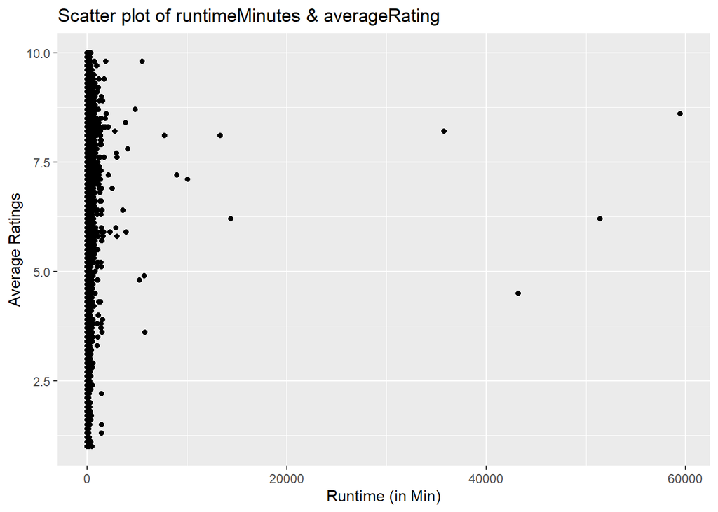

```r
ggplot(df_ratings, aes(x = runtimeMinutes, y = averageRating)) +
         geom_point()+
         labs(title = "Scatter plot of runtimeMinutes & averageRating",
              x= "Runtime (in Min)", y = "Average Ratings")
```

We can observer that there are only few movies with runtime (in Min) greater than 1000 & has more than 5 rating.  
Also, most of the movies has the rating greater than 5.

### 17: Get frequency table of “genres” variable using “plyr” package, if required and interpret it carefully

Split the “genres” variable and unnest (separate row after splitting) the resulting list column, as there are multiple values for some row

```r
genres_freq <- df_ratings %>%
  filter(!is.na(genres)) %>%
  mutate(genres = strsplit(genres, ",")) %>%
  unnest(genres) %>%
  count(genres, sort = TRUE)
knitr::kable(genres_freq)
```

| genres | n |
| --- | --- |
| Drama | 438342 |
| Comedy | 408995 |
| Action | 161999 |
| Documentary | 161760 |
| Animation | 155975 |
| Short | 155058 |
| Adventure | 143673 |
| Crime | 139541 |
| Romance | 99618 |
| Family | 94440 |
| Reality-TV | 68713 |
| Mystery | 62761 |
| Thriller | 54047 |
| Horror | 54016 |
| Fantasy | 53937 |
| Music | 43046 |
| History | 37178 |
| Talk-Show | 36419 |
| Sci-Fi | 34337 |
| Game-Show | 26716 |
| Biography | 26665 |
| Sport | 26320 |
|  | 19638 |
| Adult | 19553 |
| News | 17686 |
| Western | 15945 |
| War | 14205 |
| Musical | 12557 |
| Film-Noir | 883 |

### 18: Create a “by_genres” object using group_by function with df_ratings data and genres variable

```r
by_genres <- df_ratings %>%
  filter(!is.na(genres)) %>%
  group_by(genres)

knitr::kable(head(by_genres))
```

| tconst | averageRating | numVotes | titleType | primaryTitle | originalTitle | isAdult | startYear | endYear | runtimeMinutes | genres |
| --- | --- | --- | --- | --- | --- | --- | --- | --- | --- | --- |
| tt0000001 | 5.7 | 1965 | short | Carmencita | Carmencita | 0 | 1894 | NA | 1 | Documentary,Short |
| tt0000002 | 5.8 | 262 | short | Le clown et ses chiens | Le clown et ses chiens | 0 | 1892 | NA | 5 | Animation,Short |
| tt0000003 | 6.5 | 1807 | short | Pauvre Pierrot | Pauvre Pierrot | 0 | 1892 | NA | 4 | Animation,Comedy,Romance |
| tt0000004 | 5.6 | 178 | short | Un bon bock | Un bon bock | 0 | 1892 | NA | 12 | Animation,Short |
| tt0000005 | 6.2 | 2603 | short | Blacksmith Scene | Blacksmith Scene | 0 | 1893 | NA | 1 | Comedy,Short |
| tt0000006 | 5.1 | 179 | short | Chinese Opium Den | Chinese Opium Den | 0 | 1894 | NA | 1 | Short |

### 19: Get mean of runtimeMinutes variables using summarise function by genres, remove NA in runtimeMinutes if required

```r
mean_runtimes <- summarise(by_genres, mean_runtime = mean(runtimeMinutes, na.rm = TRUE))
knitr::kable(head(mean_runtimes))
```

| genres | mean_runtime |
| --- | --- |
| Action | 100.75626 |
| Action,Adult | 93.68182 |
| Action,Adult,Adventure | 114.33333 |
| Action,Adult,Animation | 34.12000 |
| Action,Adult,Comedy | 117.70833 |
| Action,Adult,Crime | 107.84615 |

### 20: Get mean of runtimeMinutes variables using summarise by genres without creating “by_genres” object

```r
mean_runtimes <- df_ratings %>%
  filter(!is.na(genres)) %>%
  group_by(genres) %>%
  summarise(mean_runtime = mean(runtimeMinutes, na.rm = TRUE))

knitr::kable(head(mean_runtimes))
```

| genres | mean_runtime |
| --- | --- |
| Action | 100.75626 |
| Action,Adult | 93.68182 |
| Action,Adult,Adventure | 114.33333 |
| Action,Adult,Animation | 34.12000 |
| Action,Adult,Comedy | 117.70833 |
| Action,Adult,Crime | 107.84615 |

### 21: What is difference between step 19 and step 20? Which one do you prefer? Why? Interpret the result of your choice.

The difference in step 19 & step 20 is that in step 19, by_genres object is created & then used for summarizing runtimeMinutes.  
For summarizing, I will prefer step 20 as that won’t create additional object & won’t consume extra memory. But if there will be multiple operations using by_genres, then I will prefer step 19.

### 22: Filter “df_ratings” data with runtimeMinutes less than 150 minutes and save it as “df_ratings_movie150m”

```r
df_ratings_movie150m <- df_ratings %>% filter(runtimeMinutes < 150 & !is.na(runtimeMinutes))
```

### 23: Get scatterplot of runtimeMinutes and averageRating variable for this new data and interpret then carefully

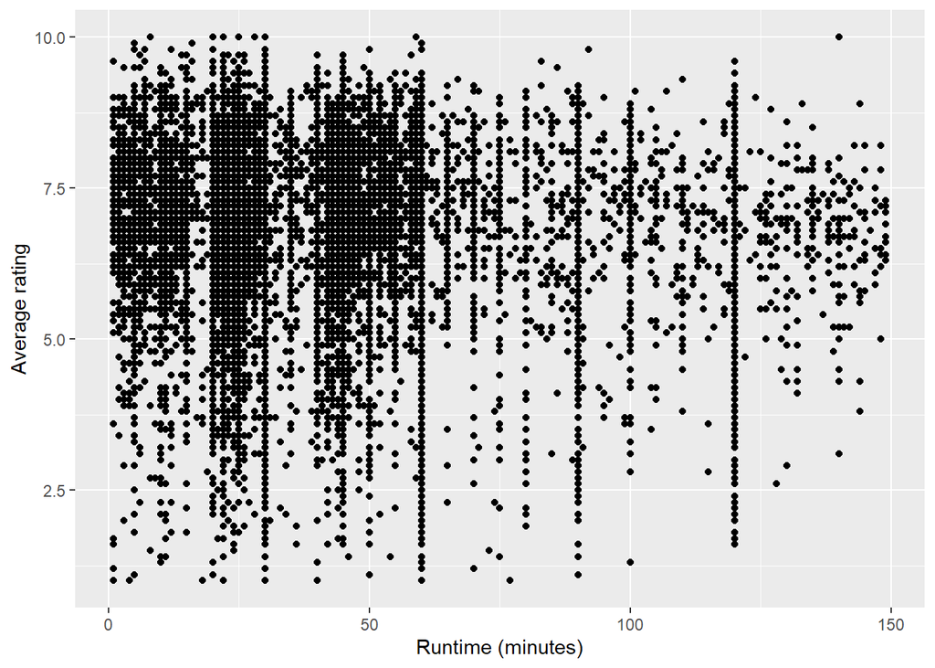

```r
ggplot(na.omit(df_ratings_movie150m), aes(x = runtimeMinutes, y = averageRating)) +
  geom_point() +
  labs(x = "Runtime (minutes)", y = "Average rating")
```

From scatterplot we can observe that there are movies with runtime less than 60, also such movies with less runtime have higher ratings

### 24: Arrange the df_rating_movie150m data in descending order by averageRating and save it as “best_worst_movies”

```r
best_worst_movies <- df_ratings_movie150m %>%
  arrange(desc(averageRating))
```

### 25: Show the top 6 and last 6 movies based on the arranged dataset above

```r
head(best_worst_movies, 6)
```

```
## # A tibble: 6 × 11
##   tconst    averageRating numVotes titleType primaryTitle  originalTitle isAdult
##   <chr>             <dbl>    <dbl> <chr>     <chr>         <chr>           <dbl>
## 1 tt0127236            10       23 video     Renegades 2   Renegades 2         1
## 2 tt0160316            10       14 movie     Girls Loving… Girls Loving…       1
## 3 tt0236477            10       12 tvMovie   Die Marquise… Die Marquise…       0
## 4 tt0237125            10       20 short     Cradle Song   Cradle Song         0
## 5 tt0258117            10       12 short     Sally in Our… Sally in Our…       0
## 6 tt0270900            10       20 tvMovie   Crumbles let… Crumbles let…       0
## # ℹ 4 more variables: startYear <dbl>, endYear <dbl>, runtimeMinutes <dbl>,
## #   genres <chr>
```

```r
tail(best_worst_movies, 6)
```

```
## # A tibble: 6 × 11
##   tconst    averageRating numVotes titleType primaryTitle  originalTitle isAdult
##   <chr>             <dbl>    <dbl> <chr>     <chr>         <chr>           <dbl>
## 1 tt9266684             1        7 tvEpisode Binge Eating… Binge Eating…       0
## 2 tt9278160             1      136 tvSpecial Genderquake:… Genderquake:…       0
## 3 tt9673398             1      125 movie     I Respond to… Odazivam Ti …       0
## 4 tt9673442             1      129 movie     Blood and Mu… Krv i mosus         0
## 5 tt9865282             1        9 movie     13 Needles    Gui men shi …       0
## 6 tt9908574             1        8 tvSeries  Maika Barbero Maika Barbero       0
## # ℹ 4 more variables: startYear <dbl>, endYear <dbl>, runtimeMinutes <dbl>,
## #   genres <chr>
```

### 26: Get the averageRating of adult movies (isAdult variable) using mutate function and interpret it carefully

```r
adult_avg_rating <- df_ratings %>% mutate(isAdult = as.logical(isAdult)) %>%
                    filter(isAdult) %>%
                    summarise(avg_rating = mean(averageRating, na.rm = TRUE))
adult_avg_rating
```

```
## # A tibble: 1 × 1
##   avg_rating
##        <dbl>
## 1       6.34
```

The average rating for adult movies is 6.34 which means on average the adult movies ratings are above average i.e. 5

#### 27: Divide the “df_ratings_movies150m” into training and testing dataset with 80% and 20% split with slice function

```r
set.seed(123)
df_train <- df_ratings_movie150m %>% slice_sample(prop = 0.8)
df_test <- df_ratings_movie150m %>% slice_sample(prop = 0.2)

knitr::kable(head(df_train))
```

| tconst | averageRating | numVotes | titleType | primaryTitle | originalTitle | isAdult | startYear | endYear | runtimeMinutes | genres |
| --- | --- | --- | --- | --- | --- | --- | --- | --- | --- | --- |
| tt0408214 | 8.7 | 10 | short | Stanley Marshall’s Myth | Stanley Marshall’s Myth | 0 | 2004 | NA | 27 | Short |
| tt0246713 | 6.7 | 32 | movie | Jahan Pyar Miley | Jahan Pyar Miley | 0 | 1969 | NA | 138 | Drama,Family |
| tt0217142 | 7.3 | 1393 | tvMovie | A Warning to the Curious | A Warning to the Curious | 0 | 1972 | NA | 50 | Drama,Horror,Mystery |
| tt3336822 | 6.2 | 37 | tvSeries | Amada Anime Series: Super Mario | Amada Anime Series: Super Mario | 0 | 1989 | NA | 39 | Adventure,Animation,Comedy |
| tt0522980 | 5.9 | 103 | tvEpisode | Toil and Trouble | Toil and Trouble | 0 | 1997 | NA | 44 | Drama,Romance |
| tt1041244 | 7.0 | 179 | tvMovie | Star Wars Tech | Star Wars Tech | 0 | 2007 | NA | 44 | Documentary |

```r
knitr::kable(head(df_test))
```

| tconst | averageRating | numVotes | titleType | primaryTitle | originalTitle | isAdult | startYear | endYear | runtimeMinutes | genres |
| --- | --- | --- | --- | --- | --- | --- | --- | --- | --- | --- |
| tt1270482 | 6.8 | 33 | movie | We’ve Never Been to Venice | Nikoli nisva sla v Benetke | 0 | 2008 | NA | 62 | Drama |
| tt19359356 | 7.9 | 46 | tvEpisode | Alola | Alola | 0 | 2022 | NA | 44 | Drama |
| tt0989159 | 7.9 | 113 | tvEpisode | Miss Harriet | Miss Harriet | 0 | 2007 | NA | 60 | Comedy,Drama |
| tt5143966 | 8.4 | 176 | short | Hysteria | Hysteria | 0 | 2016 | NA | 15 | Action,Drama,Short |
| tt17554366 | 8.1 | 11 | short | Subtotals | Majmouan | 0 | 2022 | NA | 15 | Documentary,Short |
| tt1890717 | 8.9 | 113 | tvEpisode | Big Time Single | Big Time Single | 0 | 2011 | NA | 24 | Comedy,Drama,Family |

### 28: Get mean, standard deviation, median and interquartile range of averageRating, numVotes and runtimeMinutes variable of training and testing data and interpret them carefully

```r
train_summary <- df_train %>%
  summarize(mean_rating = mean(averageRating),
            sd_rating = sd(averageRating),
            median_rating = median(averageRating),
            iqr_rating = IQR(averageRating),
            mean_votes = mean(numVotes),
            sd_votes = sd(numVotes),
            median_votes = median(numVotes),
            iqr_votes = IQR(numVotes),
            mean_runtime = mean(runtimeMinutes, na.rm = TRUE),
            sd_runtime = sd(runtimeMinutes, na.rm = TRUE),
            median_runtime = median(runtimeMinutes, na.rm = TRUE),
            iqr_runtime = IQR(runtimeMinutes, na.rm = TRUE))

test_summary <- df_test %>%
  summarise(mean_rating = mean(averageRating),
            sd_rating = sd(averageRating),
            median_rating = median(averageRating),
            IQR_rating = IQR(averageRating),
            mean_votes = mean(numVotes),
            sd_votes = sd(numVotes),
            median_votes = median(numVotes),
            IQR_votes = IQR(numVotes),
            mean_runtime = mean(runtimeMinutes, na.rm = TRUE),
            sd_runtime = sd(runtimeMinutes, na.rm = TRUE),
            median_runtime = median(runtimeMinutes, na.rm = TRUE),
            IQR_runtime = IQR(runtimeMinutes, na.rm = TRUE))

train_summary
```

```
## # A tibble: 1 × 12
##   mean_rating sd_rating median_rating iqr_rating mean_votes sd_votes
##         <dbl>     <dbl>         <dbl>      <dbl>      <dbl>    <dbl>
## 1        6.86      1.34           7.1        1.7      1317.   18175.
## # ℹ 6 more variables: median_votes <dbl>, iqr_votes <dbl>, mean_runtime <dbl>,
## #   sd_runtime <dbl>, median_runtime <dbl>, iqr_runtime <dbl>
```

```r
test_summary
```

```
## # A tibble: 1 × 12
##   mean_rating sd_rating median_rating IQR_rating mean_votes sd_votes
##         <dbl>     <dbl>         <dbl>      <dbl>      <dbl>    <dbl>
## 1        6.86      1.34           7.1        1.7      1353.   17773.
## # ℹ 6 more variables: median_votes <dbl>, IQR_votes <dbl>, mean_runtime <dbl>,
## #   sd_runtime <dbl>, median_runtime <dbl>, IQR_runtime <dbl>
```

### 29: Get histogram of averageRating, numVotes and runtimeMinutes variables of training and testing data; compare them and interpret them carefully

*Histograms for training data*

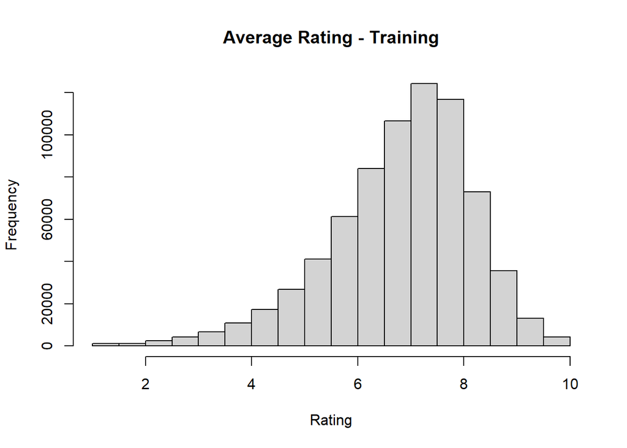

```r
hist(df_train$averageRating, main = "Average Rating - Training", xlab = "Rating")
```

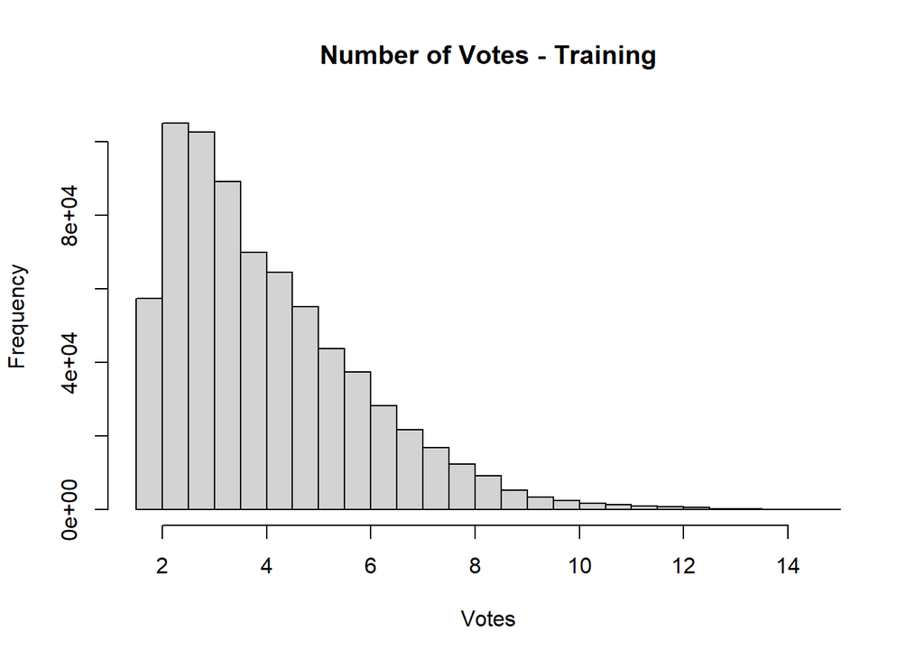

```r
hist(log(df_train$numVotes), main = "Number of Votes - Training", xlab = "Votes")
```

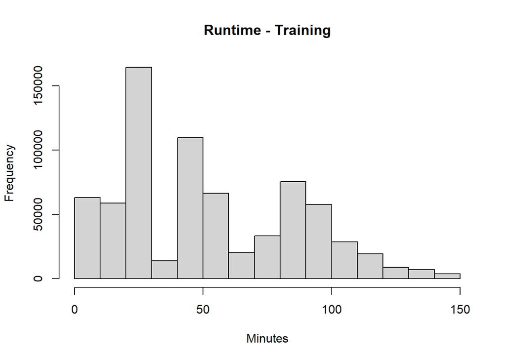

```r
hist(df_train$runtimeMinutes, main = "Runtime - Training", xlab = "Minutes")
```

*Histograms for testing data*

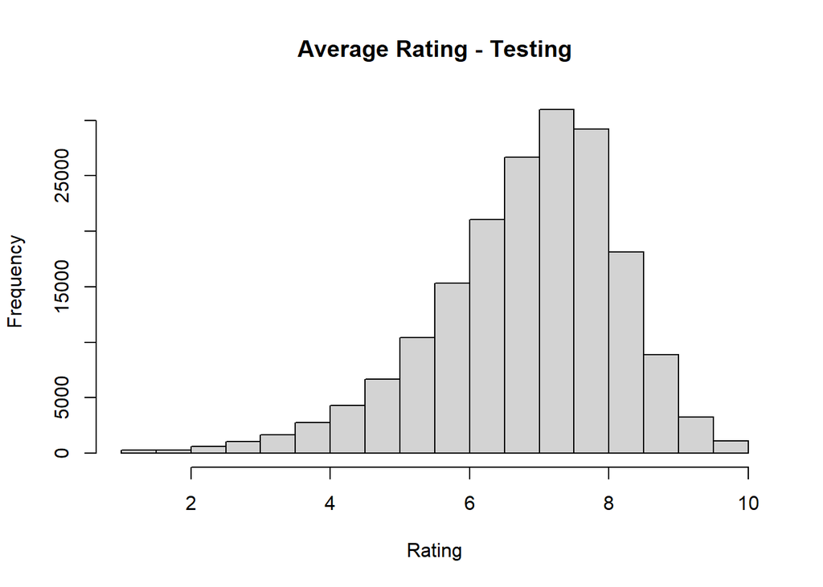

```r
hist(df_test$averageRating, main = "Average Rating - Testing", xlab = "Rating")
```

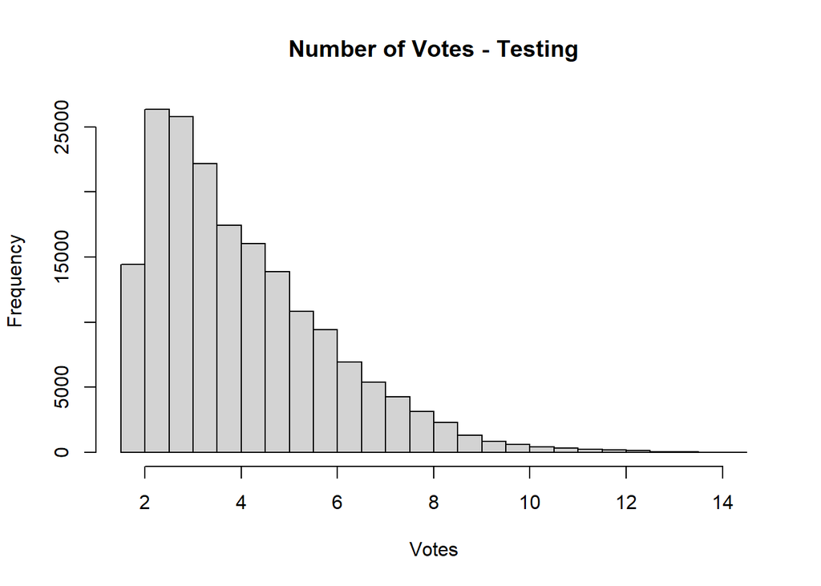

```r
hist(log(df_test$numVotes), main = "Number of Votes - Testing", xlab = "Votes")
```

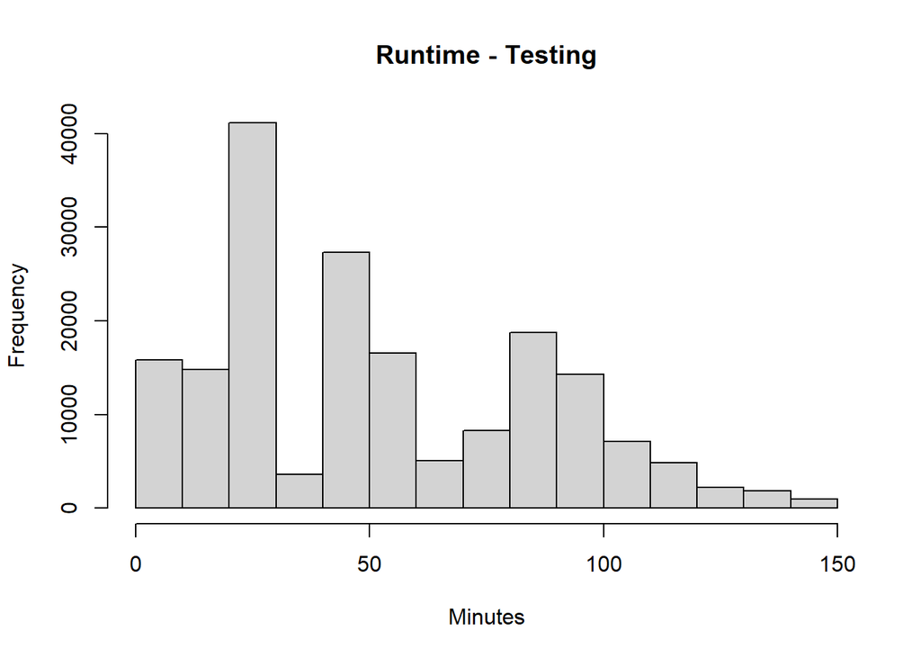

```r
hist(df_test$runtimeMinutes, main = "Runtime - Testing", xlab = "Minutes")
```

### 30: Get boxplot of averageRating, numVotes and runtimeMinutes variables of training and testing data; compare them and interpret them carefully

*Boxplot for training data*

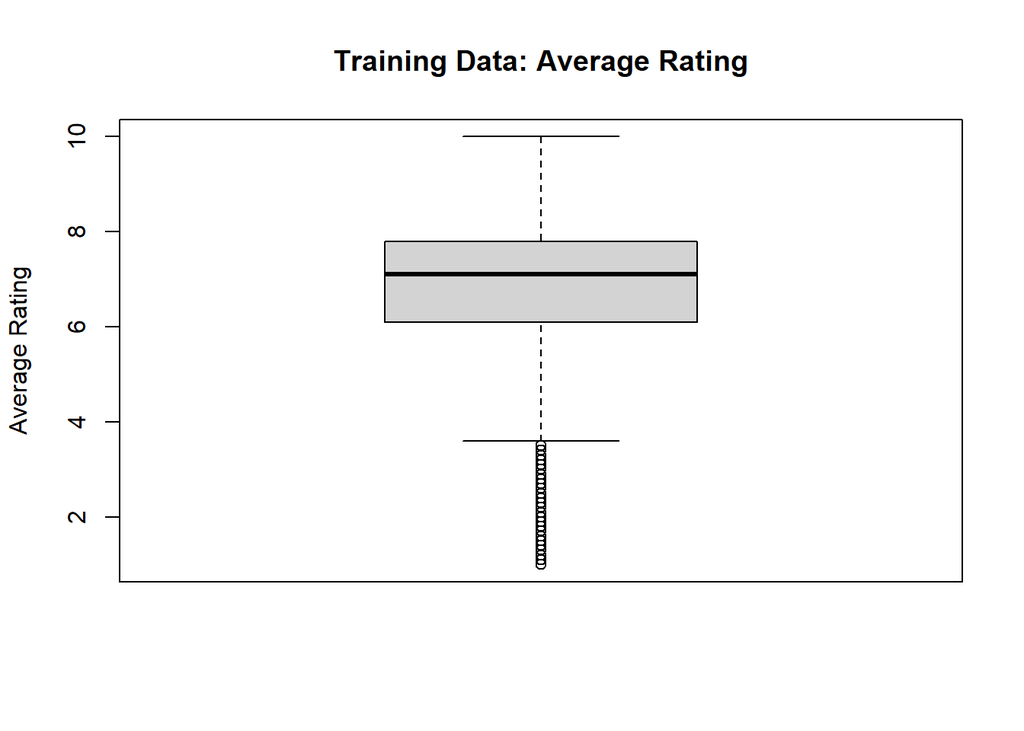

```r
boxplot(df_train$averageRating, main = "Training Data: Average Rating", ylab = "Average Rating")
```

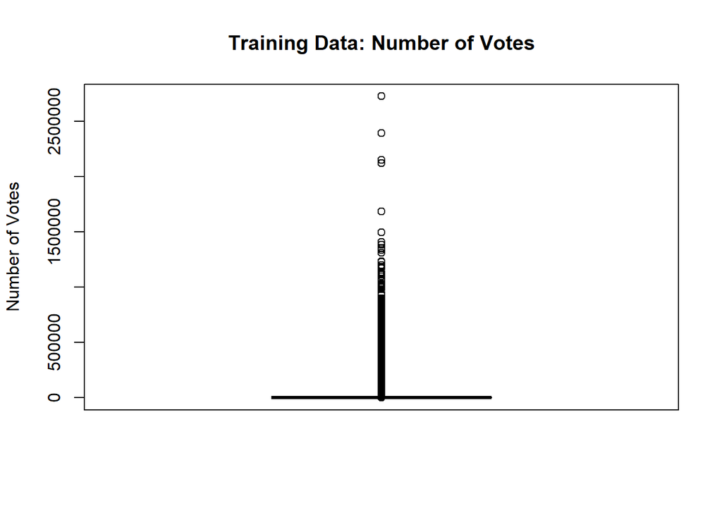

```r
boxplot(df_train$numVotes, main = "Training Data: Number of Votes", ylab = "Number of Votes")
```

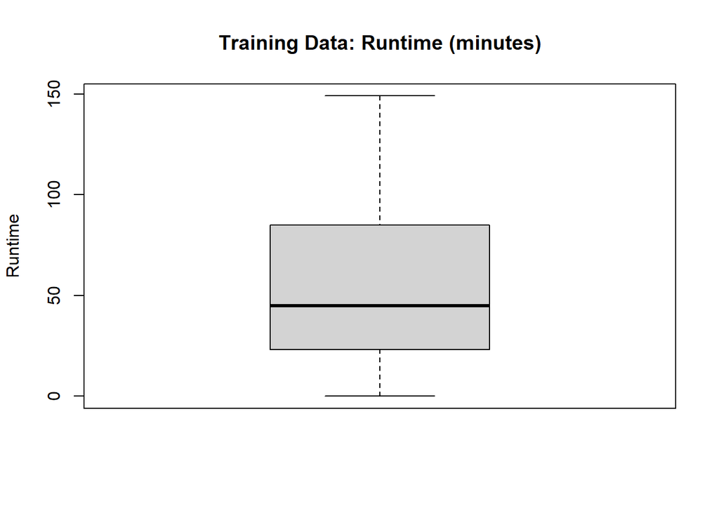

```r
boxplot(df_train$runtimeMinutes, main = "Training Data: Runtime (minutes)", ylab = "Runtime")
```

*Boxplot for testing data*

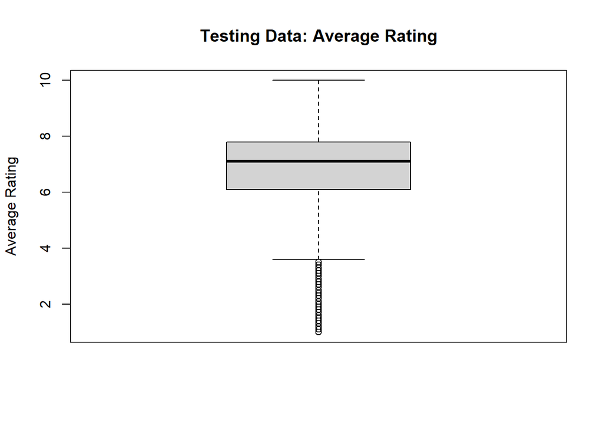

```r
boxplot(df_test$averageRating, main = "Testing Data: Average Rating", ylab = "Average Rating")
```

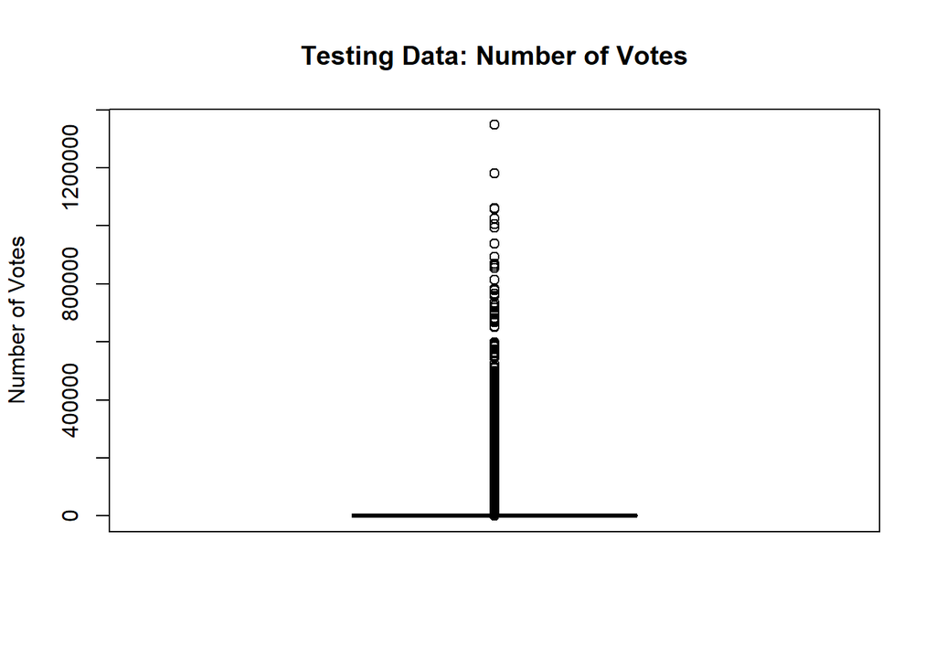

```r
boxplot(df_test$numVotes, main = "Testing Data: Number of Votes", ylab = "Number of Votes")
```

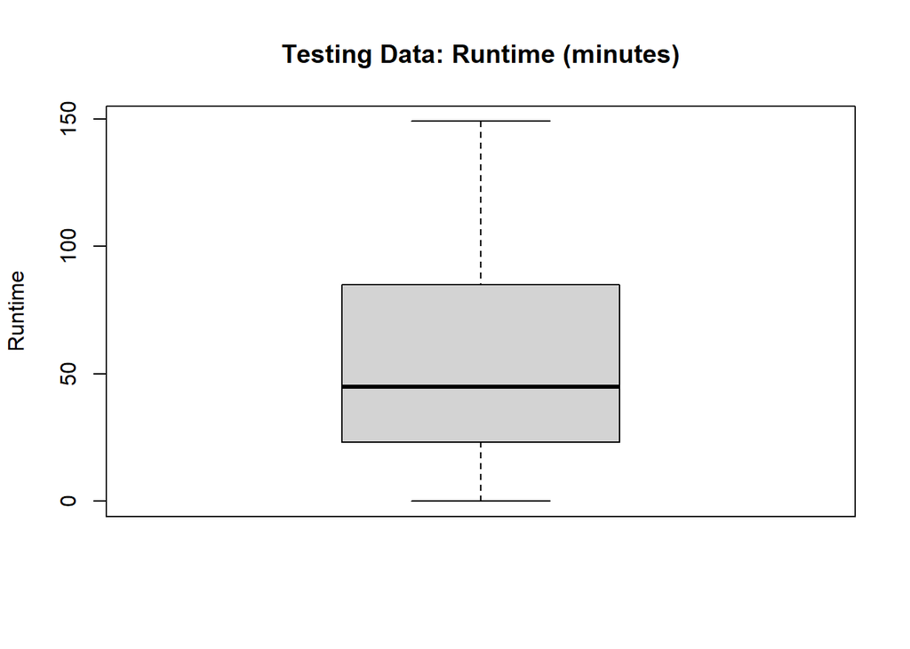

```r
boxplot(df_test$runtimeMinutes, main = "Testing Data: Runtime (minutes)", ylab = "Runtime")
```